# Анализ временных рядов авиаперевозок AirFrance

Бэлла Долганова

2026-02-06

## Executive Summary

Проведён анализ ежемесячных данных о пассажиропотоке AirFrance с целью выявления ключевых закономерностей и построения прогностической модели.

Анализ показал устойчивый восходящий тренд и выраженную годовую сезонность (период 12 месяцев). Пассажиропоток увеличивается в среднем на **≈48 пассажиров ежемесячно**, что свидетельствует о стабильном росте объёма перевозок.

Модель может быть использована для краткосрочного прогнозирования и планирования пассажирских перевозок с учётом сезонных пиков и общего тренда роста.

Для анализа используются исторические данные о пассажиропотоке авиакомпании AirFrance. На первом этапе мы загружаем данные и преобразуем текстовые даты в формат, пригодный для статистического анализа.

|  | Airline | Passengers | Date |
| --- | --- | --- | --- |
| 1 | Air France | 12050 | 2005-07-01 |
| 2 | Air France | 11230 | 2005-08-01 |
| 3 | Air France | 10731 | 2005-09-01 |
| 4 | Air France | 10515 | 2005-10-01 |
| 5 | Air France | 7121 | 2005-11-01 |
| 6 | Air France | 7158 | 2005-12-01 |
| 7 | Air France | 7565 | 2006-01-01 |
| 8 | Air France | 6469 | 2006-02-01 |
| 9 | Air France | 8444 | 2006-03-01 |
| 10 | Air France | 11648 | 2006-04-01 |

[output cut: 119 more lines]

На основе очищенных данных мы формируем объект временного ряда с ежемесячной частотой.

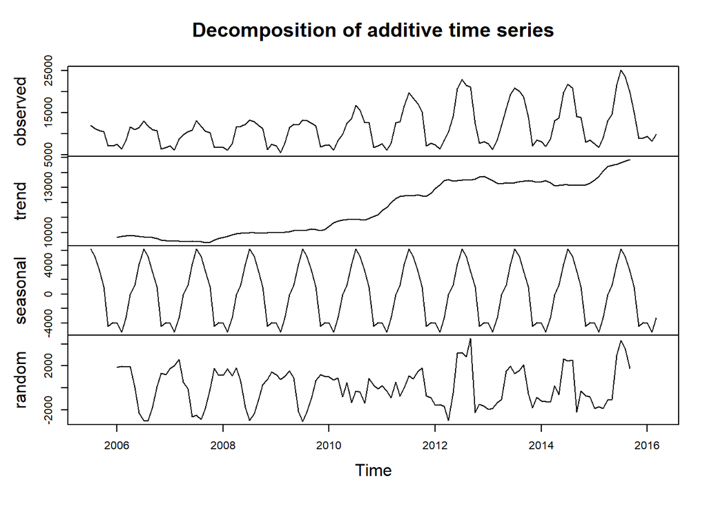

Для более детального изучения наложим компоненту тренда и сезонности на фактические данные. Это помогает оценить, насколько хорошо выбранная модель описывает реальное поведение ряда.

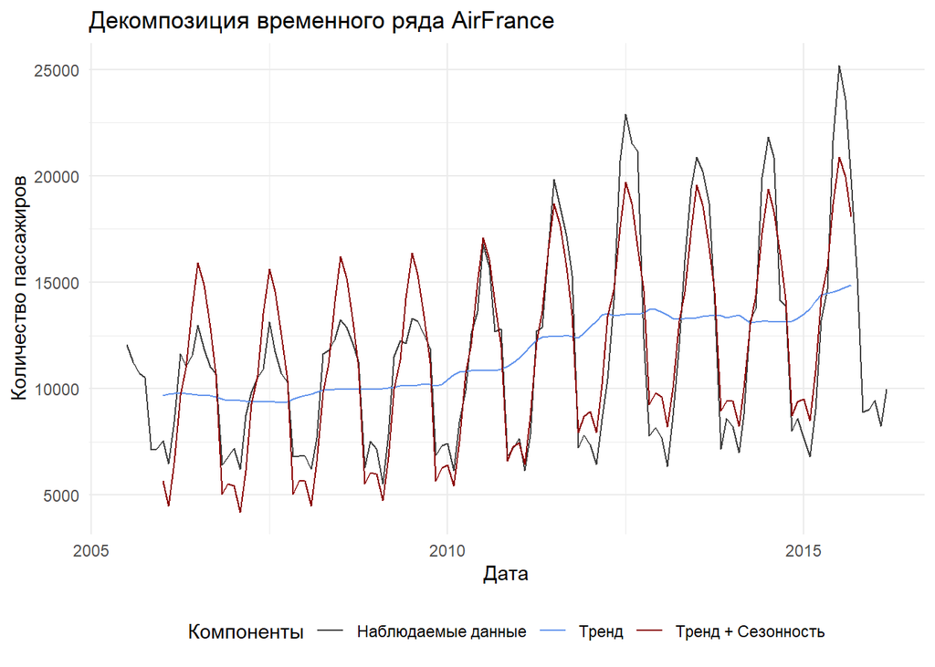

Построение автокорреляционной функции необходимо для подтверждения сезонности. Наличие значимых лагов (превышающих синюю пунктирную линию) через каждые 12 месяцев подтверждает строгую годовую цикличность данных.

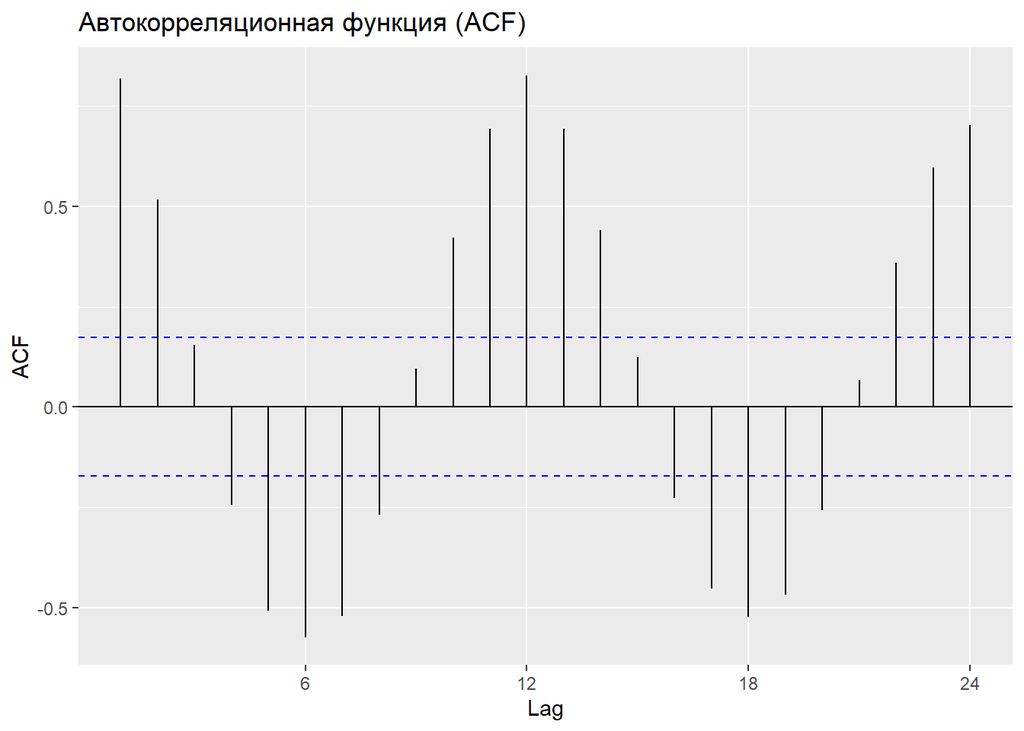

Мы используем линейную регрессию, где время выступает как предиктор тренда, а месяцы — как категориальные переменные для учета сезонности.

```
##
## Call:
## lm(formula = Observed ~ time_idx + month, data = df_ap)
##
## Residuals:
##    Min     1Q Median     3Q    Max
##  -3583  -1313   -347   1342   5400
##
## Coefficients:
##             Estimate Std. Error t value Pr(>|t|)
## (Intercept)  4435.88     663.12   6.689 8.31e-10 ***
## time_idx       48.01       4.61  10.413  < 2e-16 ***
## month2      -1192.28     829.85  -1.437    0.153
## month3        801.62     829.89   0.966    0.336
## month4       4112.35     850.44   4.836 4.11e-06 ***
## month5       5421.34     850.38   6.375 3.85e-09 ***
## month6       8284.83     850.34   9.743  < 2e-16 ***
## month7      10103.67     830.30  12.169  < 2e-16 ***
## month8       9063.30     830.16  10.918  < 2e-16 ***
## month9       7169.02     830.04   8.637 3.62e-14 ***
## month10      5061.93     829.95   6.099 1.44e-08 ***
## month11      -341.62     829.89  -0.412    0.681
## month12       118.82     829.85   0.143    0.886
## ---
## Signif. codes:  0 '***' 0.001 '**' 0.01 '*' 0.05 '.' 0.1 ' ' 1
##
## Residual standard error: 1946 on 116 degrees of freedom
## Multiple R-squared:  0.8397, Adjusted R-squared:  0.8231
## F-statistic: 50.62 on 12 and 116 DF,  p-value: < 2.2e-16
```

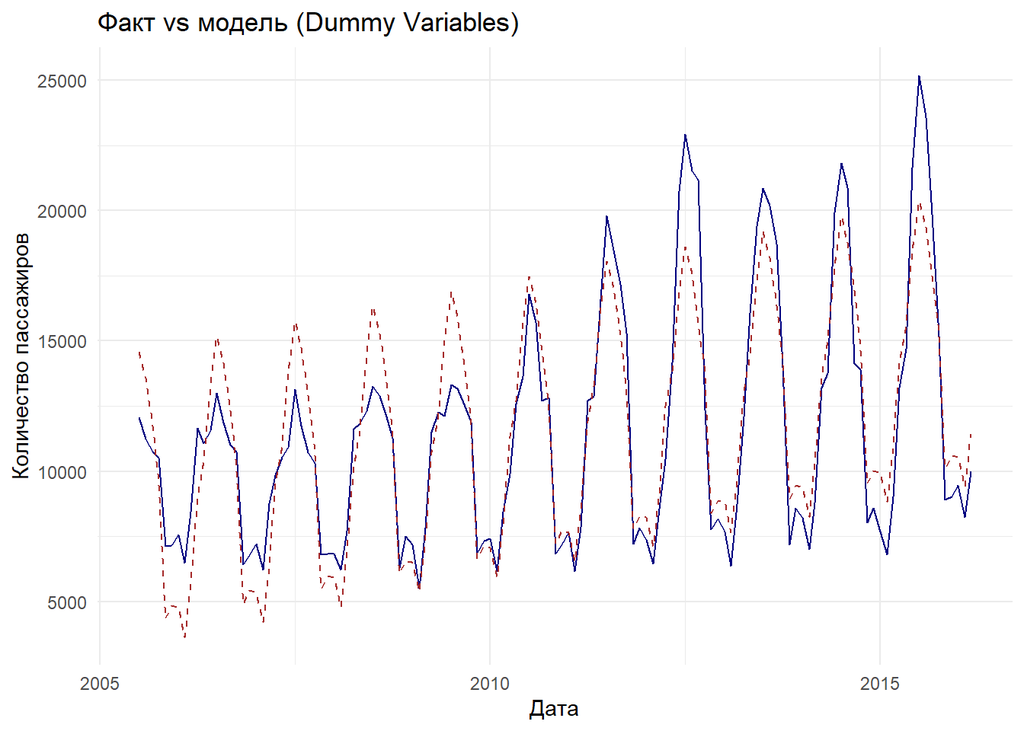

F-statistic и связанное с ним p-значение подтверждают общую статистическую значимость модели. Для более гибкого моделирования сезонных колебаний применим тригонометрические функции (синус и косинус).

Из результатов можно сделать следующие выводы: коэффициент детерминации R2≈0.806R2≈0.806 говорит о высокой объясняющей способности модели; все коэффициенты статистически значимы (p < 0.001); среднеквадратичная ошибка остатков около 2062; высокая F-статистика подтверждает значимость модели; коэффициент при t положителен (около 47.79), что указывает на рост наблюдаемой переменной с течением времени; коэффициенты при синусоидальных компонентах отражают выраженную сезонность с периодом 12 месяцев. Таким образом, гармоническая регрессия успешно моделирует тренд и сезонность, позволяя эффективно анализировать и прогнозировать динамику временного ряда

```
##
## Call:
## lm(formula = Observed ~ t + sin(2 * pi * t/12) + cos(2 * pi *
##     t/12), data = df_ap)
##
## Residuals:
##     Min      1Q  Median      3Q     Max
## -3837.7 -1625.8  -234.4  1436.9  5543.7
##
## Coefficients:
##                    Estimate Std. Error t value Pr(>|t|)
## (Intercept)        8505.434    365.696  23.258   <2e-16 ***
## t                    47.790      4.883   9.787   <2e-16 ***
## sin(2 * pi * t/12) 3038.664    256.114  11.864   <2e-16 ***
## cos(2 * pi * t/12) 4438.555    257.985  17.205   <2e-16 ***
## ---
## Signif. codes:  0 '***' 0.001 '**' 0.01 '*' 0.05 '.' 0.1 ' ' 1
##
## Residual standard error: 2062 on 125 degrees of freedom
## Multiple R-squared:  0.806,  Adjusted R-squared:  0.8013
## F-statistic: 173.1 on 3 and 125 DF,  p-value: < 2.2e-16
```

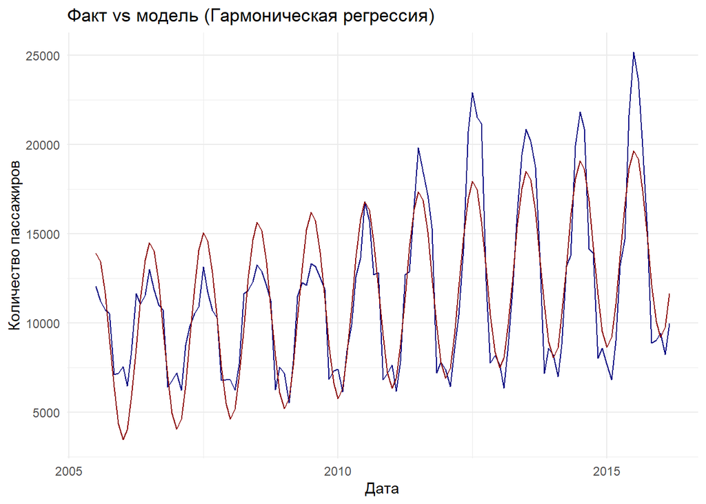

Ряд демонстрирует стабильный рост, что свидетельствует о расширении деятельности компании или росте рынка.Выявлены значимые пики пассажиропотока, связанные с сезонными факторами.Качество моделей: Обе модели показали высокий коэффициент детерминации (R2), что говорит об их адекватности и возможности использования для краткосрочного планирования.